# Introduction to DOPE

# DEA

This is a summary of the the drugs on the DEA website. It include drug class (i.e., stimulants, depressants, hallucinogens), categories (i.e., amphetamines, cocaine, barbiturates) and drug synonyms. Synonyms include brand/generic names (Adderall®, Vallium®, clonazepam) and street names (Apache, White Girl). Eventually the ontology needs to be expanded to add a grouping variable for related synonyms. For example, the generic clonazepam, the brand name Klonopin® and the street name *k-pin* all should be grouped with the general name clonazepam

## Fact Sheets

- *dea_factsheets.rda* (N = 29 records) has 10 drug classes and 29 categories (e.g., amphetamines, barbiturates, etc.). One extra class “benzodiazepine” was added because it is a grouping class in the DEA slang file.

| Class |
| --- |
| cannabis |
| depressants |
| designer drugs |
| drugs of concern |
| hallucinogen |
| heroin |
| inhalant |
| narcotics (opioids) |
| steroids |
| stimulants |

## Drug Brands

- *dea_brands.rda* (N = 28 records) has 8 drug categories (e.g., amphetamines, barbiturates, benzodiazepines, etc.) and 28 brands (e.g., Adderall®, Concerta®, etc.)

## PDFs

Two pdfs, with slang[^1] and controlled substances[^2] were download and processed to make *slang.rda* and *controlled.rda*.

## Slang

- *dea_street_names.rda* (N = 1731 records) contains 26 drug categories and 3 brands (e.g., Klonopin, Percocet, Xanax).
  - Note Percocet® is here as a category but it is not in the scraped files.
  - Several extra categories are in the slang file including: Hydrocodone, Crack Cocaine, Marijana Concentrates, PCP and Promethazine with Codeine.
  - Discrepancies, relative to the fact sheets, include *psilocybin* listed as *Mushrooms*, *bath salts* listed as *Synthetic Cathinones*, *synthetic marijuana* listed as *Synthetic Cannabinoids*.
  - There are dpulicate terms (e.g., Ace, Alice, Azucar)

## Controlled Substances

- *dea_controlled.rda* (N = 732 records) has these variables
  - `substance`: Chemical and/or brand names
  - `number`:
  - `schedule`: I, II, III, IV or V
  - `narcotic`: Y or N
  - `synonym`: Chemical and/or brand names

## DEA Summary

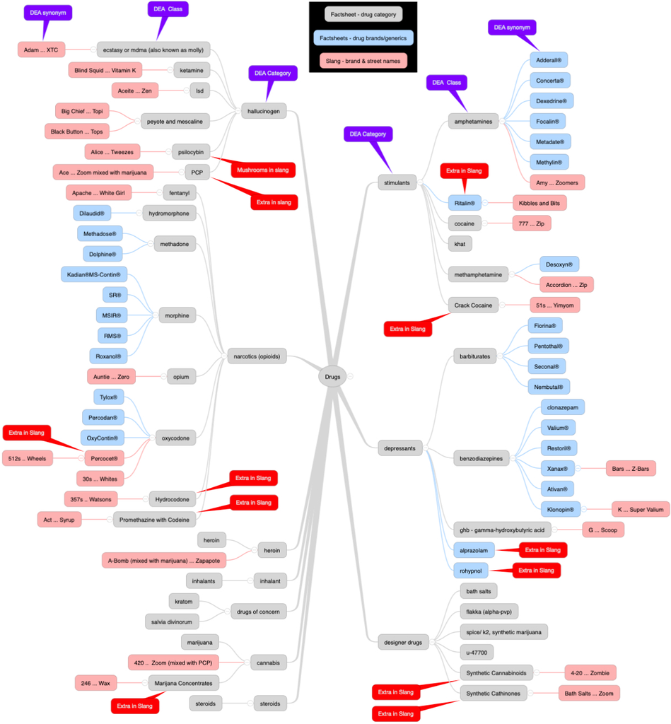

Figure 1 shows the DEA website drug ontology. Problematic entries shown with a red callout.

There are several things (in the black box) that need to be placed in the tree. Things with the red call out are inconsistencies.

# No Slang

This is a summary of the the drugs on the no slang website.

## Web Scrape

One file, *noslang_street_names.rda* , was created by scraping the [*Drug Slang Dictionary*](https://www.noslang.com/drugs/dictionary) October 12th 2020.

- *noslang_street_names.rda* has 3216 drug related terms.

# IQVIA

Additional drugs found while processing data from IQVIA. Thanks to Edward Nunes M.D. for providing notes on how to better classify these drugs. This data introduced new classes such as reversal agents and treatment drugs.

# `drug_stop_words.rda`

This is a vector of drug-specific stop words that have been observed while processing data from the aforementioned data sources. This vector is primarily used with the `parse()` function and is used to remove irrelevant words (i.e., “pills”, “syringe”) or strings such as units or dosages of drugs (i.e., “mg”).

[^1]: https://www.dea.gov/sites/default/files/resource-center/Publications/Intel%20Products/DIR-020-17%20Drug%20Slang%20Code%20Words.pdf
[^2]: https://www.deadiversion.usdoj.gov/schedules/orangebook/c_cs_alpha.pdf